# Analysis of real estate market in St. Petersburg

## Data upload

```python
import pandas as pd
import matplotlib.pyplot as plt
import numpy as np
import seaborn as sns
df=pd.read_csv('/datasets/real_estate_data.csv', sep='\t')
```

```python
df.sample(5)
```

|  | total_images | last_price | total_area | first_day_exposition | rooms | ceiling_height | floors_total | living_area | floor | is_apartment | ... | kitchen_area | balcony | locality_name | airports_nearest | cityCenters_nearest | parks_around3000 | parks_nearest | ponds_around3000 | ponds_nearest | days_exposition |
| --- | --- | --- | --- | --- | --- | --- | --- | --- | --- | --- | --- | --- | --- | --- | --- | --- | --- | --- | --- | --- | --- |
| 10002 | 12 | 3200000.0 | 35.5 | 2018-01-12T00:00:00 | 1 | 2.6 | 12.0 | 16.4 | 11 | NaN | ... | 8.1 | 2.0 | посёлок Мурино | NaN | NaN | NaN | NaN | NaN | NaN | 337.0 |
| 15480 | 13 | 3995000.0 | 48.0 | 2019-03-27T00:00:00 | 2 | NaN | 12.0 | 28.0 | 5 | NaN | ... | 7.0 | NaN | Кронштадт | 65568.0 | 47294.0 | 1.0 | 146.0 | 1.0 | 293.0 | 29.0 |
| 3753 | 11 | 8500000.0 | 94.7 | 2017-04-24T00:00:00 | 3 | NaN | 3.0 | 62.6 | 2 | NaN | ... | 9.1 | 0.0 | Санкт-Петербург | 23691.0 | 3232.0 | 0.0 | NaN | 3.0 | 386.0 | 115.0 |
| 5921 | 20 | 29000000.0 | 215.0 | 2017-12-29T00:00:00 | 5 | NaN | 5.0 | 80.0 | 3 | NaN | ... | 23.0 | NaN | Санкт-Петербург | 24887.0 | 5455.0 | 1.0 | 443.0 | 0.0 | NaN | 24.0 |
| 5632 | 20 | 13000000.0 | 95.3 | 2019-01-05T00:00:00 | 3 | 2.5 | 15.0 | 51.0 | 9 | NaN | ... | 16.6 | NaN | Санкт-Петербург | 38505.0 | 7765.0 | 1.0 | 496.0 | 2.0 | 219.0 | NaN |

5 rows × 22 columns

```python
df.info()
```

```
<class 'pandas.core.frame.DataFrame'>
RangeIndex: 23699 entries, 0 to 23698
Data columns (total 22 columns):
 #   Column                Non-Null Count  Dtype
---  ------                --------------  -----
 0   total_images          23699 non-null  int64
 1   last_price            23699 non-null  float64
 2   total_area            23699 non-null  float64
 3   first_day_exposition  23699 non-null  object
 4   rooms                 23699 non-null  int64
 5   ceiling_height        14504 non-null  float64
 6   floors_total          23613 non-null  float64
 7   living_area           21796 non-null  float64
 8   floor                 23699 non-null  int64
 9   is_apartment          2775 non-null   object
 10  studio                23699 non-null  bool
 11  open_plan             23699 non-null  bool
 12  kitchen_area          21421 non-null  float64
 13  balcony               12180 non-null  float64
 14  locality_name         23650 non-null  object
 15  airports_nearest      18157 non-null  float64
 16  cityCenters_nearest   18180 non-null  float64
 17  parks_around3000      18181 non-null  float64
 18  parks_nearest         8079 non-null   float64
 19  ponds_around3000      18181 non-null  float64
 20  ponds_nearest         9110 non-null   float64
 21  days_exposition       20518 non-null  float64
dtypes: bool(2), float64(14), int64(3), object(3)
memory usage: 3.7+ MB
```

There is a column containing both uppercase and lowercase letters in the name (cityCenters_nearest). For a part of the data, you will need to replace the data type from float to int in order to speed up the work with calculations later. The first_day_exposition column contains the date of publication of the announcement, for further work it will be necessary to convert this column to the date data type.

```python
df.isnull().sum()
```

```
total_images                0
last_price                  0
total_area                  0
first_day_exposition        0
rooms                       0
ceiling_height           9195
floors_total               86
living_area              1903
floor                       0
is_apartment            20924
studio                      0
open_plan                   0
kitchen_area             2278
balcony                 11519
locality_name              49
airports_nearest         5542
cityCenters_nearest      5519
parks_around3000         5518
parks_nearest           15620
ponds_around3000         5518
ponds_nearest           14589
days_exposition          3181
dtype: int64
```

The number of omissions in the locality_name column is only 49. It is difficult to make an assumption about them based on other available data. Due to their small number, we will delete these lines further.

```python
df['locality_name'].unique
```

```
<bound method Series.unique of 0            Санкт-Петербург
1             посёлок Шушары
2            Санкт-Петербург
3            Санкт-Петербург
4            Санкт-Петербург
                ...
23694        Санкт-Петербург
23695                  Тосно
23696       село Рождествено
23697        Санкт-Петербург
23698    поселок Новый Учхоз
Name: locality_name, Length: 23699, dtype: object>
```

Apparently, lemmatization for the locality_name column is not needed. In the course of further work, we will remove auxiliary words like "village/село", "village/поселок".

```python
df.describe()
```

|  | total_images | last_price | total_area | rooms | ceiling_height | floors_total | living_area | floor | kitchen_area | balcony | airports_nearest | cityCenters_nearest | parks_around3000 | parks_nearest | ponds_around3000 | ponds_nearest | days_exposition |
| --- | --- | --- | --- | --- | --- | --- | --- | --- | --- | --- | --- | --- | --- | --- | --- | --- | --- |
| count | 23699.000000 | 2.369900e+04 | 23699.000000 | 23699.000000 | 14504.000000 | 23613.000000 | 21796.000000 | 23699.000000 | 21421.000000 | 12180.000000 | 18157.000000 | 18180.000000 | 18181.000000 | 8079.000000 | 18181.000000 | 9110.000000 | 20518.000000 |
| mean | 9.858475 | 6.541549e+06 | 60.348651 | 2.070636 | 2.771499 | 10.673824 | 34.457852 | 5.892358 | 10.569807 | 1.150082 | 28793.672193 | 14191.277833 | 0.611408 | 490.804555 | 0.770255 | 517.980900 | 180.888634 |
| std | 5.682529 | 1.088701e+07 | 35.654083 | 1.078405 | 1.261056 | 6.597173 | 22.030445 | 4.885249 | 5.905438 | 1.071300 | 12630.880622 | 8608.386210 | 0.802074 | 342.317995 | 0.938346 | 277.720643 | 219.727988 |
| min | 0.000000 | 1.219000e+04 | 12.000000 | 0.000000 | 1.000000 | 1.000000 | 2.000000 | 1.000000 | 1.300000 | 0.000000 | 0.000000 | 181.000000 | 0.000000 | 1.000000 | 0.000000 | 13.000000 | 1.000000 |
| 25% | 6.000000 | 3.400000e+06 | 40.000000 | 1.000000 | 2.520000 | 5.000000 | 18.600000 | 2.000000 | 7.000000 | 0.000000 | 18585.000000 | 9238.000000 | 0.000000 | 288.000000 | 0.000000 | 294.000000 | 45.000000 |
| 50% | 9.000000 | 4.650000e+06 | 52.000000 | 2.000000 | 2.650000 | 9.000000 | 30.000000 | 4.000000 | 9.100000 | 1.000000 | 26726.000000 | 13098.500000 | 0.000000 | 455.000000 | 1.000000 | 502.000000 | 95.000000 |
| 75% | 14.000000 | 6.800000e+06 | 69.900000 | 3.000000 | 2.800000 | 16.000000 | 42.300000 | 8.000000 | 12.000000 | 2.000000 | 37273.000000 | 16293.000000 | 1.000000 | 612.000000 | 1.000000 | 729.000000 | 232.000000 |
| max | 50.000000 | 7.630000e+08 | 900.000000 | 19.000000 | 100.000000 | 60.000000 | 409.700000 | 33.000000 | 112.000000 | 5.000000 | 84869.000000 | 65968.000000 | 3.000000 | 3190.000000 | 3.000000 | 1344.000000 | 1580.000000 |

### Conclusion

The minimum value in the rooms column is '0', probably the number of rooms is not filled for studio apartments. Min also looks strange. the value is 2 m in the living area column. Something strange is happening in the ceiling_height column: there is at least 1 sq. with a ceiling height of 100 m and at least one apartment with a ceiling height of 1 m.

Judging by the fact that the maximum number in the days_exposition column is 1580, our archive of ads compiles data on apartment sales for the last 4 years at the time of data upload.

The minimum value for the total_area column is 12 sq. m., which would not be surprising if we were analyzing the real estate market, for example, in Paris, but for St. Petersburg and the region, such an area even for studio apartments seems unlikely, as well as the minimum value for the living_area column is 2 sq.m, because on this it is impossible even to place a bed on the square. The minimum recommended area for developers (in our case, the living_area column) in Russia for one-room apartments is 14 sq. m. m (https://gsps.ru/poleznoe/minimalnaya-ploshchad-pomeshcheniy-kvartiry.php ).

## Data preprocessing

```python
df = df.rename(columns={'cityCenters_nearest': 'nearest_city_center'})
#rename the incorrectly named column
```

### Missed values

```python
df.dropna(subset=['locality_name'], inplace=True)
df.dropna(subset=['floors_total'], inplace=True)

#we will delete the rows with omissions in the columns locality_name and floors_total due to their small number - 49 and 86, respectively
```

```python
display((df['balcony'].isnull().sum())/len(df['balcony']))
#let's look at the ratio of missed values in the balcony column to the total number of rows
```

```
0.486950986632718
```

It is unlikely that almost half of the apartments sold did not have balconies. Let's assume that there are no balconies in the apartments located on the 1st floor - replace them with "0". For the remaining omissions, we will leave the marker "-1".

```python
df.loc[(df.floor == 1) & (pd.isna(df.balcony)),'balcony'] == 0
df['balcony']=df['balcony'].fillna(-1)
display(df['balcony'].isnull().sum())

#fill in the gaps in the balcony column and check the remaining missing values
```

```
0
```

```python
df['is_apartment']=df['is_apartment'].fillna(False)
df['ponds_around3000']=df['ponds_around3000'].fillna(0)
df['parks_around3000']=df['parks_around3000'].fillna(0)
```

Fill in the missing values based on the assumptions that:

- missed values in the column "is_apartment" mean that these are not apartments - there are few apartments-apartments in Russia,
- missed values in the columns ponds_around3000 mean that there is no reservoir in raudis 3 km
- missed values in the parks_around3000 columns mean that there is no park in raudis 3 km away

```python
df['ceiling_height'] = df['ceiling_height'].fillna(df.groupby(['floors_total'])['ceiling_height'].transform('mean'))
```

```python
df['kitchen_area'] = df['kitchen_area'].fillna((df['total_area']-df['living_area']))
#calculate the kitchen area based on data on the total area and residential
```

```python
df['ceiling_height'] = df['ceiling_height'].fillna(df.groupby(['floors_total'])['ceiling_height'].transform('mean'))
#fill in the gaps in the ceiling_height column with average values depending on the number of floors of the house
```

```python
df['living_area'] = df['living_area'].fillna(df.groupby(['rooms'])['living_area'].transform('mean'))
#fill in the gaps in the living_area column with average values depending on the number of rooms
```

```python
df['kitchen_area'] = df['kitchen_area'].fillna(df.groupby(['living_area'])['kitchen_area'].transform('mean'))
#fill in the gaps in the living_area column with average values depending on the total area of the apartment
```

For the remaining columns with gaps, it was decided to fill in the gaps with the "-1" marker, since it is impossible to find logical replacements based on the available data, and the total share of such rows in the sample is quite large.

```python
df.loc[:,['airports_nearest','nearest_city_center','parks_nearest','ponds_nearest','days_exposition']] = df[['airports_nearest','nearest_city_center','parks_nearest','ponds_nearest','days_exposition']].fillna(-1)
```

```python
df.isnull().sum()
#let's check the number of omissions in the dataset after all the conversions
```

```
total_images             0
last_price               0
total_area               0
first_day_exposition     0
rooms                    0
ceiling_height           1
floors_total             0
living_area              0
floor                    0
is_apartment             0
studio                   0
open_plan                0
kitchen_area            12
balcony                  0
locality_name            0
airports_nearest         0
nearest_city_center      0
parks_around3000         0
parks_nearest            0
ponds_around3000         0
ponds_nearest            0
days_exposition          0
dtype: int64
```

```python
df.dropna(subset=['kitchen_area'], inplace=True)
#drop 12 rows with gaps in the kitchen_area column
```

Let's clean the column with the names of settlements from auxiliary words denoting the type of settlement and the extra spaces left after that.

```python
df['locality_name'] = df['locality_name'].str.replace('ё', 'е', regex = True) # replacing 'ё' with 'е'
#creating a list of auxiliary words
location_type = ['городской поселок', 'поселок', 'деревня', 'село', 'поселок городского типа', 'садоводческое некоммерческое товарищество', 'садовое товарищество', 'коттеджный поселок', 'коттеджный']

for type_name in location_type: #sort through the list of auxiliary words
    df['locality_name'] = df['locality_name'].replace(type_name, '', regex = True) # replace the auxiliary part with an empty string

df['locality_name'] = df['locality_name'].apply(lambda x: x.strip())
#remove the extra spaces
```

```python
display(df['locality_name'].value_counts().head(30))
#look at the result
```

```
Санкт-Петербург    15644
Мурино               585
Кудрово              470
Шушары               438
Всеволожск           397
Пушкин               369
Колпино              338
Парголово            327
Гатчина              307
Выборг               237
Петергоф             201
Сестрорецк           183
Красное Село         176
Новое Девяткино      143
Сертолово            142
Ломоносов            133
Кириши               125
Бугры                113
Сланцы               112
Волхов               111
Кингисепп            104
Тосно                103
Кронштадт             96
Никольское            94
Коммунар              89
Сосновый Бор          87
Кировск               84
Отрадное              80
Янино-1               68
Металлострой          66
Name: locality_name, dtype: int64
```

### Changing data type

```python
df['ceiling_height'] = df['ceiling_height'].round(2)
```

```python
df['first_day_exposition'] = pd.to_datetime(df['first_day_exposition'], format='%Y-%m-%dt%H:%M:%S')
```

The data for the last_price column is given in rubles, divide this column by 1000 to analyze the data in thousands of rubles.

```python
df['last_price']=df['last_price']/1000
#we translate the price data in thousand rubles
```

```python
df = df.astype({'floors_total':'int','last_price':'int'},errors='ignore')
```

### Conclusion

In order to make further calculations, the data type for the first_day_exposition column was changed. To make the code work faster, the data type in some columns was replaced from float to int for those columns where it does not cause data loss for analysis.

## Calculations and adding results to the table

```python
df['weekday_exposition']=pd.DatetimeIndex(df['first_day_exposition']).day_name()
#add the day of week of the first ad publication to the table
```

```python
df['month_exposition']=pd.DatetimeIndex(df['first_day_exposition']).month_name()
#add the month of the first ad publication to the table
```

```python
df['year_exposition'] = pd.DatetimeIndex(df['first_day_exposition']).year
#add the year of the first ad publication to the table
```

```python
df['living_to_total'] = (df['living_area']/df['total_area']).round(2)
df['kitchen_to_total'] = (df['kitchen_area']/df['total_area']).round(2)
#let's add to the table the ratio of residential and total area, as well as the ratio of kitchen area to total
```

```python
df['square_metre_price'] = (df['last_price'] / df['total_area']).round(2)
#let's add a column with the price per square meter to the table
```

```python
def define_floor_category (floors_total, floor):
    if floor == floors_total:
        return 'last'
    elif floor == 1:
        return 'first'
    else:
        return 'other'

df['floor_category'] = df.apply(lambda x: define_floor_category(x.floors_total, x.floor), axis=1)
#let's apply the apartment floor categorization function to the floor and floors_total columns and write the result of the function to a new one
#floor_category column
```

```python
df.sample(5)
```

|  | total_images | last_price | total_area | first_day_exposition | rooms | ceiling_height | floors_total | living_area | floor | is_apartment | ... | ponds_around3000 | ponds_nearest | days_exposition | weekday_exposition | month_exposition | year_exposition | living_to_total | kitchen_to_total | square_metre_price | floor_category |
| --- | --- | --- | --- | --- | --- | --- | --- | --- | --- | --- | --- | --- | --- | --- | --- | --- | --- | --- | --- | --- | --- |
| 16907 | 17 | 4200 | 50.7 | 2017-04-28 | 2 | 2.78 | 19 | 29.3 | 10 | False | ... | 1.0 | 183.0 | 39.0 | Friday | April | 2017 | 0.58 | 0.17 | 82.84 | other |
| 22116 | 20 | 3890 | 36.7 | 2017-04-18 | 1 | 2.78 | 25 | 18.7 | 16 | False | ... | 0.0 | -1.0 | 348.0 | Tuesday | April | 2017 | 0.51 | 0.26 | 105.99 | other |
| 3173 | 6 | 4800 | 44.5 | 2019-03-27 | 2 | 3.20 | 6 | 33.0 | 6 | False | ... | 0.0 | -1.0 | 26.0 | Wednesday | March | 2019 | 0.74 | 0.16 | 107.87 | last |
| 7614 | 17 | 6000 | 52.2 | 2017-01-07 | 2 | 2.62 | 12 | 31.2 | 1 | False | ... | 1.0 | 665.0 | 60.0 | Saturday | January | 2017 | 0.60 | 0.14 | 114.94 | first |
| 4608 | 10 | 11000 | 65.9 | 2018-09-27 | 2 | 3.00 | 16 | 19.7 | 13 | False | ... | 2.0 | 427.0 | 195.0 | Thursday | September | 2018 | 0.30 | 0.57 | 166.92 | other |

5 rows × 29 columns

### Conclusion

For further work, columns have been added to the dataframe that can provide additional information: the day of the week, the year and month of ad publication, the ratio of different types of areas to each other, as well as the price per sq.m.

## Exploratory data analysis

### Researching parametres

#### Number of bedrooms

```python
with pd.option_context('display.float_format', '{:.2%}'.format):
    display(df['rooms'].value_counts(normalize=True))
#let's look at the distribution of apartments by the number of rooms
```

```
1    33.98%
2    33.53%
3    24.54%
4     4.98%
5     1.38%
0     0.78%
6     0.44%
7     0.25%
8     0.05%
9     0.03%
10    0.01%
11    0.01%
14    0.01%
19    0.00%
16    0.00%
12    0.00%
15    0.00%
Name: rooms, dtype: float64
```

```python
df = df.query('0 < rooms < 6')
#we leave apartments with the number of rooms from 1 to 5
```

#### Square

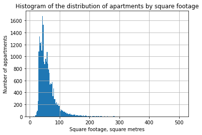

```python
df['total_area'].hist(bins=200)
plt.title('Histogram of the distribution of apartments by square footage')
plt.ylabel('Number of appartments')
plt.xlabel('Square footage, square metres')
plt.show()
#let's see how the area of apartments is distributed after the exclusion of multi-room apartments
```

According to the visualization, it can be seen that on the border of the total area of about 100 sq. m the number of apartments is halved, and after 200 sq. m becomes quite minimal. These values are small, but they can still influence the average numbers. Considering that we left the maximum possible number of rooms equal to 5, apartments with an area of 200 sq. m. (about 40 sq.m. per room) look strange. We can also notice that there are apartments with an abnormally small area, let's look at them in more detail.

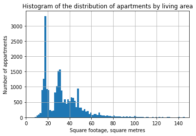

```python
df['living_area'].plot(kind='hist', bins=200, xlim=(0,150), grid=True)
plt.title('Histogram of the distribution of apartments by living area')
plt.ylabel('Number of appartments')
plt.xlabel('Square footage, square metres')
plt.show()
#let's see how the living area of apartments is distributed after the exclusion of multi-room apartments
```

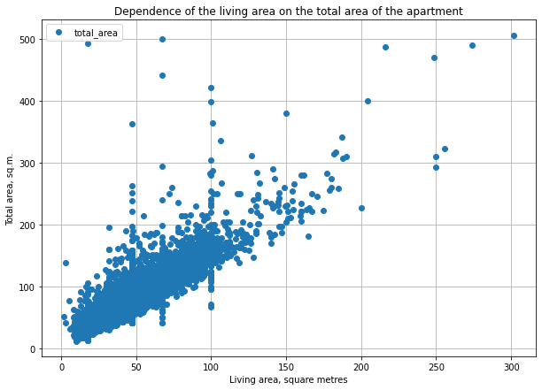

```python
df.plot(x='living_area', y='total_area', figsize=(10,7),grid=True,style='o')
plt.title('Dependence of the living area on the total area of the apartment')
plt.ylabel('Total area, sq.m.')
plt.xlabel('Living area, square metres')
plt.show()
```

```python
df = df.query('total_area <= 150')
#we will remove apartments from the analyzed data, the total area of which is more than 150 sq.m.
```

```python
display('{:.2%}'.format(len(df.query('living_area < 14'))/len(df)))
#we will find out the share of apartments whose living area is less than the federal recommended standard of 14 sq.m. in the total data array
```

```
'1.33%'
```

Only 1.3%, the share is small. For reinsurance, we will discard all apartments where the living area is less than 13 sq. m., because, for example, there are apartments with an area of 13.59 sq. m.

```python
df = df.query('living_area > 13')
#we are removing apartments with abnormally small living space
```

#### Price

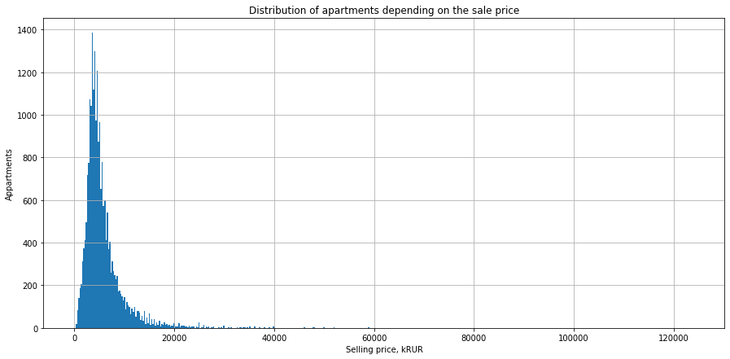

```python
df['last_price'].plot(kind = 'hist', figsize = (15,7), bins=500, grid=True)
plt.title('Distribution of apartments depending on the sale price')
plt.ylabel('Appartments')
plt.xlabel('Selling price, kRUR')
plt.show()
```

Now the histogram is shifted to the left, there is an unusual peak for apartments whose cost is more than 60 million rubles. There are only 3 peaks of values in the segment where the cost of apartments is more than 10 million rubles. Let's discard abnormally high values.

```python
df=df.query('last_price<=15000')
#let's discard all values where the sale price is more than 15 million rubles
```

#### Ceiling height

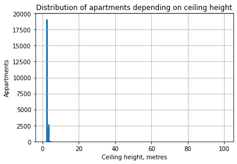

```python
df['ceiling_height'].plot(kind='hist', bins=100, grid=True)
plt.title('Distribution of apartments depending on ceiling height')
plt.ylabel('Appartments')
plt.xlabel('Ceiling height, metres')
plt.show()
#let's evaluate visually with the help of a histogram whether there are many abnormally high/abnormally low values for ceiling height in the dataset
```

```python
df['ceiling_height'].describe()
```

```
count    21844.000000
mean         2.754235
std          1.013768
min          1.000000
25%          2.600000
50%          2.700000
75%          2.790000
max        100.000000
Name: ceiling_height, dtype: float64
```

The maximum ceiling height of 100 m seems unlikely, as does the minimum - 1 m. Most ceilings are in the range from 0 to 10 m.

```python
len(df.query('ceiling_height > 4'))
#find out the exact number of objects in which the ceiling height is more than 4 meters
```

```
53
```

```python
len(df.query('ceiling_height<2.4'))
#find out the exact number of objects in which the ceiling height is less than 2.4 meters
```

```
21
```

The minimum ceiling height in apartments in Russia is 2.4 m. In Stalinist houses, the ceiling height can reach 3.5 m. The number of rows with an abnormally low /abnormally high ceiling height value is small in the dataset, so we will delete these rows.

```python
df=df.query('2.4<ceiling_height<4')
#we cut off the lines where the ceiling height is less than 2.4 m and greater than / equal to 4 m
```

#### Time needed to sale the apartment

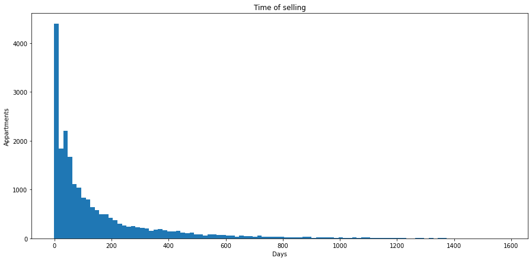

```python
df['days_exposition'].plot(kind = 'hist', figsize = (15,7), bins=100)
plt.title('Time of selling')
plt.ylabel('Appartments')
plt.xlabel('Days')
plt.show()
```

```python
df_days_exposition=df.query('days_exposition != "-1"')
df_days_exposition['days_exposition'].describe()
#let's remove the lines where there are gaps and look at the descriptive statistics
```

```
count    21723.000000
mean       154.113244
std        209.791654
min         -1.000000
25%         24.000000
50%         73.000000
75%        194.500000
max       1580.000000
Name: days_exposition, dtype: float64
```

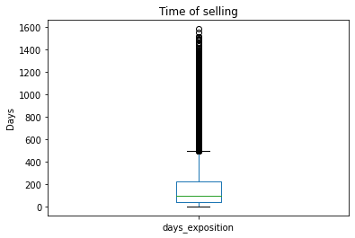

```python
df_days_exposition=df.query('days_exposition != -1')
df_days_exposition['days_exposition'].plot(kind='box')
plt.title('Time of selling')
plt.ylabel('Days')
plt.show()
```

### What factors most affect the cost of an apartment

Let's look at the distribution of apartments by parameters after processing abnormal values.

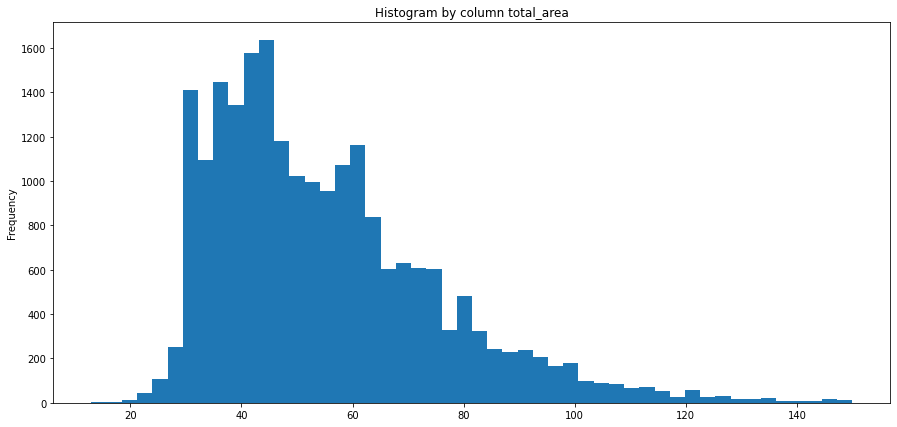

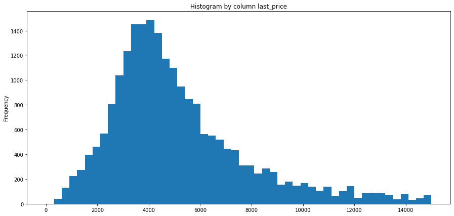

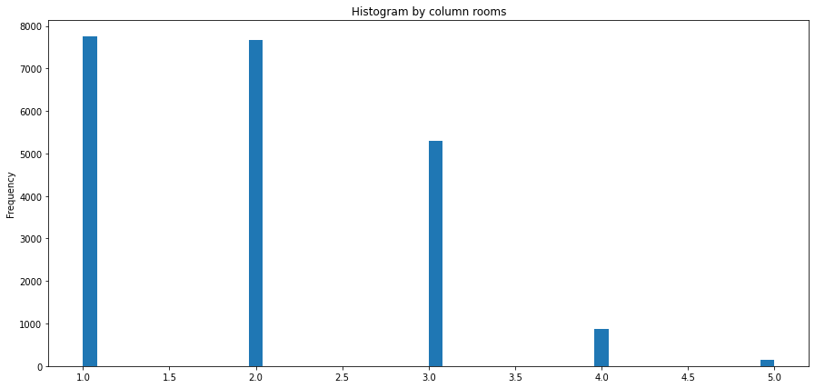

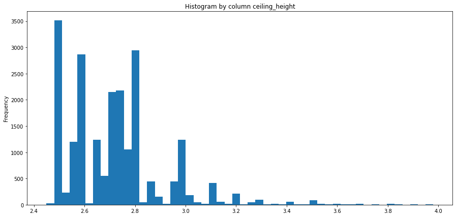

```python
list_of_columns = ['total_area', 'last_price', 'rooms', 'ceiling_height']

for column in list_of_columns:
    df[column].plot(kind = 'hist', figsize = (15,7), bins=50)
    plt.title('Histogram by column ' + column)
    plt.show()
```

The histogram for the ceiling_height column shows the influence of a typical building with a standard ceiling height: the graph is very intermittent. The main part of the apartments in the analyzed data are two-room and one-room apartments. Most of all, the form of distribution of the price of an apartment is similar to the form of distribution of apartments by area.

```python
for column in list_of_columns:
    corr = df[column].corr(df['square_metre_price'], method='pearson')
    with pd.option_context('display.float_format', '{:.2%}'.format):
        display('Correlation coefficient between the price per sq.m. and '+column+': {:.2%}'.format(corr))
```

```
'Correlation coefficient between the price per sq.m. and total_area: 1.72%'
```

```
'Correlation coefficient between the price per sq.m. and last_price: 64.88%'
```

```
'Correlation coefficient between the price per sq.m. and rooms: -16.48%'
```

```
'Correlation coefficient between the price per sq.m. and ceiling_height: 16.53%'
```

Based on the earlier categorization of apartments by number of floors, we will find out the average price per sq. m. for the group.

```python
with pd.option_context('display.float_format', '{:.2f}'.format):
    display(df.groupby('floor_category').agg(average_price_for_square_meter_kRUR=('square_metre_price','mean')))
```

| floor_category | average_price_for_square_meter_kRUR |
| --- | --- |
| first | 79.51 |
| last | 84.71 |
| other | 97.38 |

Apartments on the ground floors are the cheapest, then there are apartments on the last, but most of all buyers prefer apartments located on the middle floors.

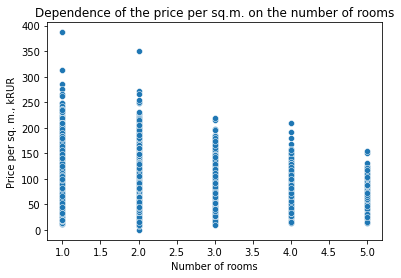

```python
sns.scatterplot(data = df, x = "rooms", y = "square_metre_price")
plt.title('Dependence of the price per sq.m. on the number of rooms')
plt.ylabel('Price per sq. m., kRUR')
plt.xlabel('Number of rooms')
plt.show()
#посмотрим диаграмму рассеяния по столбцам square_metre_price и rooms
```

The larger the apartment by area, the lower the price per sq. m. will be in it, despite the fact that the total cost of the apartment is always more.

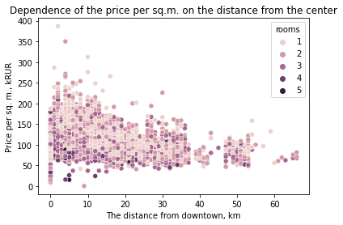

```python
df['nearest_city_center_km']=round((df['nearest_city_center']/1000),)
sns.scatterplot(data = df, x = "nearest_city_center_km", y = "square_metre_price", hue="rooms")
plt.title('Dependence of the price per sq.m. on the distance from the center')
plt.ylabel('Price per sq. m., kRUR')
plt.xlabel('The distance from downtown, km')
plt.show()
#let's look at the scattering diagram of the distance from the center and the price per sq.m., having previously converted the distance from m to km
```

There is a decreasing relationship between the distance from the center and the price per square meter: the greater the distance, the lower the price. Multi-room apartments, painted with dark shades, are located closer to the lower left corner of the graph: the more rooms in the apartment, the lower the price for each sq.m. will be.

```python
df_clean=df.query('nearest_city_center_km > -1')
corr = df_clean['nearest_city_center_km'].corr(df['square_metre_price'], method='pearson')
display(corr)
```

```
0.1674812293724476
```

```python
with pd.option_context('display.float_format', '{:.2f}'.format):
    display(df.groupby('weekday_exposition').agg(average_price_for_square_meter_kRUR=('square_metre_price','mean')).sort_values(by='average_price_for_square_meter_kRUR',ascending=False))
#we will find out the average price per sq. m. for the group by the days of the week of ad placement
```

| weekday_exposition | average_price_for_square_meter_kRUR |
| --- | --- |
| Tuesday | 94.13 |
| Wednesday | 93.64 |
| Friday | 93.53 |
| Monday | 93.17 |
| Thursday | 93.12 |
| Sunday | 92.80 |
| Saturday | 91.91 |

Considering the average values of the sale price per sq.m., on Saturdays, apartment owners are most unsure that the object can be sold profitably, and the most expensive apartments are placed on Tuesdays.

```python
with pd.option_context('display.float_format', '{:.2f}'.format):
    display(df.groupby('month_exposition').agg(average_price_for_square_meter_kRUR=('square_metre_price','mean')).sort_values(by='average_price_for_square_meter_kRUR',ascending=False))
#we will find out the average price per sq. m. for the group by months of ad placement
```

| month_exposition | average_price_for_square_meter_kRUR |
| --- | --- |
| April | 95.15 |
| September | 94.69 |
| August | 94.27 |
| March | 93.70 |
| November | 93.59 |
| May | 93.54 |
| January | 93.32 |
| October | 92.85 |
| July | 92.75 |
| February | 92.72 |
| December | 92.21 |
| June | 90.60 |

Judging by the average values of the sale price per sq.m., apartment prices increase in the spring (all 3 spring months are located in the upper half of the table) and at the beginning of the school year. The cheapest apartments are trying to sell in June.

```python
with pd.option_context('display.float_format', '{:.2f}'.format):
    display(df.groupby('year_exposition').agg(average_price_for_square_meter_kRUR=('square_metre_price','mean')).sort_values(by='year_exposition'))
#calculate the average price depending on the year of publication of the ad
```

| year_exposition | average_price_for_square_meter_kRUR |
| --- | --- |
| 2014 | 100.69 |
| 2015 | 92.94 |
| 2016 | 91.02 |
| 2017 | 91.47 |
| 2018 | 93.41 |
| 2019 | 100.47 |

Considering the average values of the sale price per sq.m., apartment prices decreased in the period 2014-2017, and then went up again.

```python
display(df['locality_name'].value_counts().head(10))
#let's choose 10 localities with the largest number of ads
```

```
Санкт-Петербург    14085
Мурино               546
Кудрово              441
Шушары               424
Всеволожск           383
Пушкин               345
Колпино              334
Парголово            309
Гатчина              304
Выборг               229
Name: locality_name, dtype: int64
```

```python
town_list=['Санкт-Петербург','Мурино','Кудрово','Шушары','Всеволожск','Пушкин','Колпино','Парголово','Гатчина','Выборг']
df_most_popular=df.query('locality_name in @town_list')
#filter data

with pd.option_context('display.float_format', '{:.2f}'.format):
    display(df_most_popular.groupby('locality_name').agg(average_price_for_square_meter_kRUR=('square_metre_price','mean')).sort_values(by='average_price_for_square_meter_kRUR',ascending=False))
#we calculate the average price by suburbs
```

| locality_name | average_price_for_square_meter_kRUR |
| --- | --- |
| Санкт-Петербург | 107.04 |
| Пушкин | 101.21 |
| Кудрово | 95.09 |
| Парголово | 90.06 |
| Мурино | 85.34 |
| Шушары | 77.78 |
| Колпино | 75.32 |
| Гатчина | 69.00 |
| Всеволожск | 67.13 |
| Выборг | 58.01 |

The lowest cost of housing among the 10 largest settlements on offer is in Vyborg and Vsevolozhsk, and the highest is in St. Petersburg and Pushkin. The upper value (the cost of sq. m. in St. Petersburg) is 1.85 times higher than the lower one (Vyborg).

```python
with pd.option_context('display.float_format', '{:.2f}'.format):
    display(
df.groupby('locality_name').square_metre_price.agg(['count','mean']).sort_values('count', ascending=False).head(10).sort_values('mean', ascending=False))
```

| locality_name | count | mean |
| --- | --- | --- |
| Санкт-Петербург | 14085 | 107.04 |
| Пушкин | 345 | 101.21 |
| Кудрово | 441 | 95.09 |
| Парголово | 309 | 90.06 |
| Мурино | 546 | 85.34 |
| Шушары | 424 | 77.78 |
| Колпино | 334 | 75.32 |
| Гатчина | 304 | 69.00 |
| Всеволожск | 383 | 67.13 |
| Выборг | 229 | 58.01 |

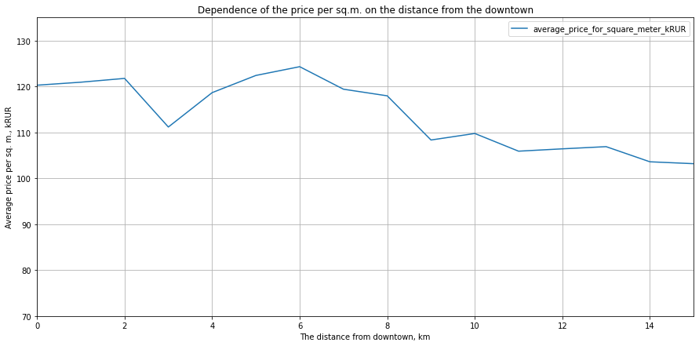

```python
df_st_peter = df.query('locality_name=="Санкт-Петербург"')
#filter data

df_st_peter_fin=df_st_peter.groupby('nearest_city_center_km').agg(average_price_for_square_meter_kRUR=('square_metre_price','mean')).sort_values(by='nearest_city_center_km').reset_index()

df_st_peter_fin.plot(x='nearest_city_center_km', figsize = (15,7), grid=True, xlim=(0,15))
plt.title('Dependence of the price per sq.m. on the distance from the downtown')
plt.ylabel('Average price per sq. m., kRUR')
plt.xlabel('The distance from downtown, km')
plt.show()
```

The graph of the dependence of the price per sq. m. on the distance to the center reaches its maximum at around 6 km. Then the price per sq. m. decreases. It can be concluded that the central zone in St. Petersburg is outlined by a zone of 6 km.

### The segment of apartments in the downtown

Let's see if there are any peculiarities in pricing for apartments located in the central zone.

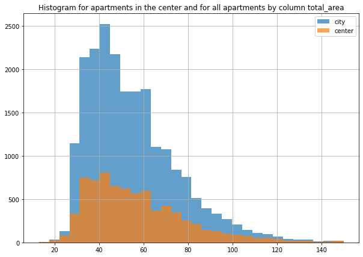

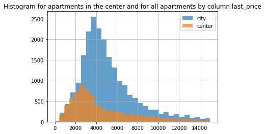

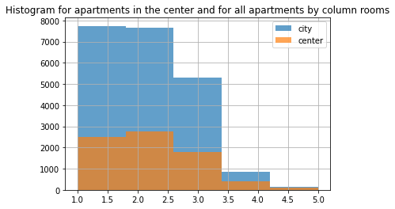

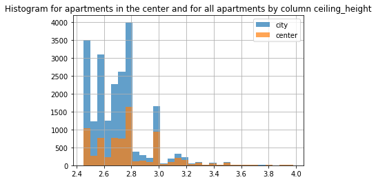

```python
df_center=df.query('nearest_city_center_km <= 6')
#we will allocate apartments in the center to a separate dataframe

#let's build normalized histograms according to 4 parameters, and superimpose them on each other, coloring the apartments from the main dataframe pink
list_of_columns = ['total_area', 'last_price', 'rooms', 'ceiling_height']

fig = plt.figure(figsize=(10,7))

for column in list_of_columns:

    bins = min(df_center[column].nunique(), 30)

    df[column].hist(bins = bins, alpha = 0.7, label='city')
    df_center[column].hist(bins = bins, alpha = 0.7, label='center')

    plt.title('Histogram for apartments in the center and for all apartments by column ' + column)
    plt.legend(loc=0)
    plt.show()
```

The histograms show that the distributions of apartments in the center differ significantly only in the last_price parameter. Let's study what parameters the price depends on.

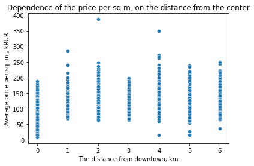

```python
sns.scatterplot(data = df_center, x = "nearest_city_center_km", y = "square_metre_price")
plt.title('Dependence of the price per sq.m. on the distance from the center')
plt.ylabel('Average price per sq. m., kRUR')
plt.xlabel('The distance from downtown, km')
plt.show()
#let's look at the scattering diagram of distance from the center and prices per sq.m.
```

Within a radius of 0-6 km from the center, it is difficult to talk about some strong dependence of the price of an apartment on the distance from the center.

```python
with pd.option_context('display.float_format', '{:.2f}'.format):
    display(df_center.groupby('weekday_exposition').agg(average_price_for_square_meter_kRUR=('square_metre_price','mean')).sort_values(by='average_price_for_square_meter_kRUR',ascending=False))
#let's look at the average price per square meter, depending on what day of the week the ad was placed
```

| weekday_exposition | average_price_for_square_meter_kRUR |
| --- | --- |
| Friday | 80.87 |
| Wednesday | 79.95 |
| Monday | 79.51 |
| Thursday | 78.94 |
| Tuesday | 78.26 |
| Saturday | 76.21 |
| Sunday | 74.98 |

As for the entire data set, prices on weekends are the lowest.

```python
with pd.option_context('display.float_format', '{:.2f}'.format):
    display(df_center.groupby('month_exposition').agg(average_price_for_square_meter_kRUR=('square_metre_price','mean')).sort_values(by='average_price_for_square_meter_kRUR',ascending=False))
#we will find out the average price per sq. m. for the group by months of ad placement
```

| month_exposition | average_price_for_square_meter_kRUR |
| --- | --- |
| September | 82.81 |
| May | 82.58 |
| April | 80.11 |
| November | 79.77 |
| August | 79.40 |
| March | 79.27 |
| July | 78.62 |
| October | 77.89 |
| June | 77.18 |
| February | 77.00 |
| January | 76.66 |
| December | 76.35 |

```python
with pd.option_context('display.float_format', '{:.2f}'.format):
    display(df_center.groupby('year_exposition').agg(average_price_for_square_meter_kRUR=('square_metre_price','mean')).sort_values(by='year_exposition'))
#calculate the average price depending on the year of publication of the ad
```

| year_exposition | average_price_for_square_meter_kRUR |
| --- | --- |
| 2014 | 72.38 |
| 2015 | 87.97 |
| 2016 | 80.14 |
| 2017 | 79.30 |
| 2018 | 76.41 |
| 2019 | 80.76 |

```python
with pd.option_context('display.float_format', '{:.2f}'.format):
    display(df_center.groupby('floor_category').agg(average_price_for_square_meter_kRUR=('square_metre_price','mean')))
```

| floor_category | average_price_for_square_meter_kRUR |
| --- | --- |
| first | 66.09 |
| last | 70.58 |
| other | 84.28 |

As with the entire data set, for apartments in the center, the objects on the first and last floors are the cheapest.

```python
df_center_factors = df_center[['square_metre_price','floor_category','floors_total','rooms','kitchen_to_total','living_to_total','parks_around3000','ponds_around3000','last_price','floor','total_area','first_day_exposition','total_images','ceiling_height']]
#let's build a matrix of price correlation and factors influencing the pricing of apartments for apartments in the center
corr = df_center_factors.corr()

corr.style.background_gradient(cmap='coolwarm')
```

|  | square_metre_price | floors_total | rooms | kitchen_to_total | living_to_total | parks_around3000 | ponds_around3000 | last_price | floor | total_area | total_images | ceiling_height |
| --- | --- | --- | --- | --- | --- | --- | --- | --- | --- | --- | --- | --- |
| square_metre_price | 1.000000 | 0.222682 | -0.032517 | 0.179751 | -0.206585 | 0.465355 | 0.503659 | 0.768277 | 0.165479 | 0.159537 | 0.085659 | 0.343204 |
| floors_total | 0.222682 | 1.000000 | -0.271971 | 0.324683 | -0.338296 | -0.183862 | -0.136838 | 0.023552 | 0.714184 | -0.156063 | -0.031229 | -0.182173 |
| rooms | -0.032517 | -0.271971 | 1.000000 | -0.552720 | 0.528570 | 0.234107 | 0.192598 | 0.463737 | -0.195640 | 0.819234 | 0.073876 | 0.236435 |
| kitchen_to_total | 0.179751 | 0.324683 | -0.552720 | 1.000000 | -0.420320 | -0.077205 | -0.057470 | -0.134135 | 0.227754 | -0.416958 | -0.072254 | -0.046944 |
| living_to_total | -0.206585 | -0.338296 | 0.528570 | -0.420320 | 1.000000 | 0.067349 | 0.011544 | -0.019066 | -0.258477 | 0.198139 | 0.008670 | 0.060168 |
| parks_around3000 | 0.465355 | -0.183862 | 0.234107 | -0.077205 | 0.067349 | 1.000000 | 0.546941 | 0.526544 | -0.132991 | 0.325833 | 0.024677 | 0.414786 |
| ponds_around3000 | 0.503659 | -0.136838 | 0.192598 | -0.057470 | 0.011544 | 0.546941 | 1.000000 | 0.539791 | -0.103073 | 0.307131 | 0.004504 | 0.359187 |
| last_price | 0.768277 | 0.023552 | 0.463737 | -0.134135 | -0.019066 | 0.526544 | 0.539791 | 1.000000 | 0.029435 | 0.716065 | 0.099011 | 0.467796 |
| floor | 0.165479 | 0.714184 | -0.195640 | 0.227754 | -0.258477 | -0.132991 | -0.103073 | 0.029435 | 1.000000 | -0.105336 | -0.000869 | -0.138084 |
| total_area | 0.159537 | -0.156063 | 0.819234 | -0.416958 | 0.198139 | 0.325833 | 0.307131 | 0.716065 | -0.105336 | 1.000000 | 0.078854 | 0.358998 |
| total_images | 0.085659 | -0.031229 | 0.073876 | -0.072254 | 0.008670 | 0.024677 | 0.004504 | 0.099011 | -0.000869 | 0.078854 | 1.000000 | 0.026512 |
| ceiling_height | 0.343204 | -0.182173 | 0.236435 | -0.046944 | 0.060168 | 0.414786 | 0.359187 | 0.467796 | -0.138084 | 0.358998 | 0.026512 | 1.000000 |

```python
df_factors = df[['square_metre_price','floor_category','floors_total','rooms','kitchen_to_total','living_to_total','parks_around3000','ponds_around3000','last_price','floor','total_area','first_day_exposition','total_images','ceiling_height']]
#let's build a matrix of price correlation and factors affecting apartment pricing for all apartments
corr = df_factors.corr()

corr.style.background_gradient(cmap='coolwarm')
```

|  | square_metre_price | floors_total | rooms | kitchen_to_total | living_to_total | parks_around3000 | ponds_around3000 | last_price | floor | total_area | total_images | ceiling_height |
| --- | --- | --- | --- | --- | --- | --- | --- | --- | --- | --- | --- | --- |
| square_metre_price | 1.000000 | 0.317329 | -0.164840 | 0.219473 | -0.252512 | 0.277072 | 0.291179 | 0.648779 | 0.232631 | 0.017240 | 0.127300 | 0.165305 |
| floors_total | 0.317329 | 1.000000 | -0.216592 | 0.300266 | -0.382677 | -0.139885 | -0.031639 | 0.169639 | 0.675547 | -0.021240 | 0.019892 | -0.082538 |
| rooms | -0.164840 | -0.216592 | 1.000000 | -0.568811 | 0.576411 | 0.084247 | 0.064537 | 0.467174 | -0.164617 | 0.797549 | 0.079350 | 0.123362 |
| kitchen_to_total | 0.219473 | 0.300266 | -0.568811 | 1.000000 | -0.499058 | -0.068937 | -0.011569 | -0.137842 | 0.209768 | -0.381591 | -0.063340 | 0.044921 |
| living_to_total | -0.252512 | -0.382677 | 0.576411 | -0.499058 | 1.000000 | 0.059653 | -0.024670 | -0.019940 | -0.274333 | 0.197513 | -0.003383 | -0.047556 |
| parks_around3000 | 0.277072 | -0.139885 | 0.084247 | -0.068937 | 0.059653 | 1.000000 | 0.380187 | 0.266047 | -0.095593 | 0.119300 | 0.018267 | 0.193218 |
| ponds_around3000 | 0.291179 | -0.031639 | 0.064537 | -0.011569 | -0.024670 | 0.380187 | 1.000000 | 0.294774 | -0.021433 | 0.146505 | -0.003050 | 0.178539 |
| last_price | 0.648779 | 0.169639 | 0.467174 | -0.137842 | -0.019940 | 0.266047 | 0.294774 | 1.000000 | 0.120199 | 0.740732 | 0.156318 | 0.338365 |
| floor | 0.232631 | 0.675547 | -0.164617 | 0.209768 | -0.274333 | -0.095593 | -0.021433 | 0.120199 | 1.000000 | -0.024163 | 0.036771 | -0.055711 |
| total_area | 0.017240 | -0.021240 | 0.797549 | -0.381591 | 0.197513 | 0.119300 | 0.146505 | 0.740732 | -0.024163 | 1.000000 | 0.103134 | 0.301012 |
| total_images | 0.127300 | 0.019892 | 0.079350 | -0.063340 | -0.003383 | 0.018267 | -0.003050 | 0.156318 | 0.036771 | 0.103134 | 1.000000 | -0.011769 |
| ceiling_height | 0.165305 | -0.082538 | 0.123362 | 0.044921 | -0.047556 | 0.193218 | 0.178539 | 0.338365 | -0.055711 | 0.301012 | -0.011769 | 1.000000 |

### Conclusion

For apartments in the center, the number of storeys of the building is not as important as for the general array of apartments - perhaps this is due to the peculiarities of typical buildings in Russia, whereas in the center of St. Petersburg, the number of storeys is the same for the main part of the houses.

The larger the share of the kitchen in the total area of the apartment, the higher the price for it, and an increase in the share of living space to the total area of the apartment negatively affects its price.

The presence of parks and ponds within a radius of 3 km has a much stronger impact on apartments in the center than in the whole data set. The effect of the number of rooms on the total cost of the apartment is the same for both groups.

## General conclusion

Most of all, the cost of apartments is influenced by such factors as the number of rooms, the total area of the apartment, the kitchen area, ceiling height.

There is a pattern between the price per sq. m. and the date of placement of the ad: on weekends, prices in publications are lower.

At the same time, there are features for apartments in the center that should be taken into account when building a model.

For apartments in the center, their location is no longer important: apartments on the "border" of the central zone cost the same as apartments located in its center. For apartments in the center, the fact that there are ponds or parks nearby, the ceiling height plays a much greater importance than in the whole data set.